# Exploratory Analysis

DJ, Sai and Pranav

11/22/2021

## Introduction

Our group is interested in the field/domain of COVID vaccination in America. We are interested in this, because it’s data relevant to how our lives will proceed in these next few months and years, as public health and the end of the pandemic depends on the rate of vaccination. Our team is interested in seeing how different parts of the US are proceeding in terms of vaccination, fully vaccinated people, and how many of the doses they are using, since there’s been talks of vaccine doses wastage. The data set we’re using was collected by Our World In Data. For global vaccination data, metrics were drawn from the latest revision of the United Nations World Population Prospects. For United States vaccination data, which is the metrics we’re relying on, the values were taken from daily updated data by the United States Centers for Disease Control and Prevention. We focused on the United States data to inform our understanding on how vaccination efforts are going in our country.

## Aggregate Table

US Vaccine Tracker

| location | total_vax | total_dist | total_dist_per_100 | people_vax | people_vax_per_100 | people_full_vax | people_fullvax_per_100 | daily_vax_average | daily_vax_per_million | percentage_of_doses_used |
| --- | --- | --- | --- | --- | --- | --- | --- | --- | --- | --- |
| Alabama | 948797808 | 1419114990 | 92 | 555761253 | 36 | 424079674 | 28 | 15972 | 3257 | 65 |
| Alaska | 183280595 | 244983765 | 108 | 99368196 | 44 | 82298650 | 36 | 2875 | 3930 | 73 |
| Arizona | 1796275719 | 2229965560 | 98 | 983166320 | 43 | 778074103 | 34 | 29326 | 4029 | 78 |
| Arkansas | 647219434 | 874750615 | 92 | 370780739 | 39 | 281592718 | 30 | 11038 | 3658 | 72 |
| California | 11117209364 | 13236501425 | 106 | 6401626227 | 51 | 4849080618 | 39 | 182322 | 4614 | 80 |
| Colorado | 1606522677 | 1877763295 | 104 | 872278301 | 48 | 729808740 | 40 | 26051 | 4524 | 83 |
| Connecticut | 1138414349 | 1285845640 | 115 | 630040648 | 56 | 523404734 | 47 | 18151 | 5091 | 86 |
| Delaware | 262535913 | 336339620 | 112 | 145202785 | 48 | 116027764 | 39 | 4368 | 4486 | 76 |
| District of Columbia | 217770799 | 276183090 | 132 | 110204403 | 53 | 86930986 | 42 | 3522 | 4991 | 76 |
| Florida | 5707756850 | 7100628235 | 106 | 3147778518 | 47 | 2510896469 | 37 | 94183 | 4385 | 78 |
| Georgia | 2186478279 | 3036974545 | 94 | 1219027888 | 38 | 951203186 | 29 | 37370 | 3520 | 70 |
| Hawaii | 411263343 | 507505430 | 117 | 241892835 | 56 | 174551791 | 41 | 6330 | 4471 | 78 |
| Idaho | 357282969 | 484252740 | 87 | 193513012 | 35 | 162727908 | 29 | 5728 | 3206 | 73 |
| Illinois | 2222755941 | 2662620300 | 88 | 1307068552 | 43 | 947250545 | 31 | 54294 | 4285 | 79 |
| Indiana | 1511488543 | 1874673340 | 88 | 811261183 | 38 | 696032863 | 33 | 23571 | 3501 | 79 |
| Iowa | 798634081 | 957370430 | 97 | 433334853 | 44 | 372551623 | 38 | 12725 | 4033 | 82 |
| Kansas | 687216570 | 879339935 | 96 | 398808114 | 43 | 317038091 | 35 | 11223 | 3852 | 75 |
| Kentucky | 810462589 | 977885015 | 84 | 459101153 | 39 | 365097629 | 31 | 16429 | 3677 | 81 |
| Louisiana | 973270694 | 1243264705 | 85 | 528263345 | 36 | 438925764 | 30 | 15770 | 3392 | 77 |
| Maine | 413738538 | 489688820 | 116 | 231800411 | 55 | 198026745 | 47 | 6763 | 5031 | 82 |
| Maryland | 1707905337 | 2159283880 | 116 | 944821495 | 51 | 792034658 | 43 | 28968 | 4792 | 76 |
| Massachusetts | 2217794086 | 2526713580 | 116 | 1244220889 | 57 | 1000449066 | 46 | 35407 | 5137 | 84 |
| Michigan | 2372358688 | 3026141140 | 98 | 1302339512 | 42 | 1105498135 | 36 | 39153 | 3920 | 77 |
| Minnesota | 1528872604 | 1771281640 | 100 | 842448217 | 47 | 712691984 | 40 | 25161 | 4462 | 84 |
| Mississippi | 581017197 | 819345700 | 87 | 323981653 | 35 | 259869387 | 28 | 9716 | 3265 | 69 |
| Missouri | 1391649618 | 1748154205 | 91 | 760281522 | 40 | 616044767 | 32 | 22477 | 3662 | 77 |
| Montana | 253155254 | 312326725 | 93 | 138829617 | 41 | 115169077 | 34 | 3974 | 3718 | 80 |
| Nebraska | 490293818 | 582255270 | 96 | 266272208 | 44 | 227210022 | 38 | 7828 | 4047 | 81 |
| Nevada | 746365837 | 877384715 | 90 | 418718426 | 43 | 328536251 | 34 | 12058 | 3915 | 82 |
| New Hampshire | 352957444 | 430598340 | 114 | 200894257 | 53 | 160450056 | 43 | 6448 | 4742 | 79 |
| New Jersey | 2416365080 | 2911982535 | 110 | 1390895594 | 53 | 1132634451 | 43 | 41284 | 4648 | 81 |
| New Mexico | 462654828 | 498125985 | 95 | 261364567 | 50 | 207818146 | 40 | 9478 | 4520 | 91 |
| New York State | 5666117377 | 6562427255 | 107 | 3108163558 | 51 | 2597312663 | 43 | 91245 | 4690 | 83 |
| North Carolina | 2483508210 | 3239166475 | 99 | 1402347509 | 43 | 1105774280 | 34 | 41506 | 3957 | 75 |
| North Dakota | 172017158 | 202905665 | 87 | 91494780 | 39 | 74921881 | 32 | 2666 | 3498 | 86 |
| Ohio | 2732474330 | 3363207615 | 93 | 1465982598 | 40 | 1258937596 | 35 | 43770 | 3745 | 79 |
| Oklahoma | 923762017 | 1165246565 | 93 | 511731951 | 41 | 402767078 | 32 | 14709 | 3717 | 77 |
| Oregon | 1156166353 | 1470193805 | 111 | 635894673 | 48 | 536830809 | 41 | 18941 | 4491 | 77 |
| Pennsylvania | 2738549690 | 3276851710 | 96 | 1632905998 | 48 | 1185200478 | 35 | 55775 | 4357 | 79 |
| Rhode Island | 327366649 | 392012500 | 117 | 180904185 | 54 | 152591557 | 46 | 5297 | 5000 | 80 |
| South Carolina | 1148764845 | 1512042110 | 93 | 635669332 | 39 | 511568227 | 32 | 18997 | 3690 | 75 |
| South Dakota | 211366976 | 260736730 | 98 | 117786300 | 44 | 96739755 | 36 | 3430 | 3878 | 81 |
| Tennessee | 1483543765 | 1879583400 | 88 | 799051407 | 37 | 644879145 | 30 | 24531 | 3592 | 76 |
| Texas | 6726498093 | 8690890060 | 98 | 3699921351 | 42 | 2948958379 | 33 | 112677 | 3886 | 76 |
| Utah | 752990901 | 887416980 | 89 | 418186366 | 42 | 321046560 | 32 | 12398 | 3867 | 84 |
| Vermont | 173992410 | 204050605 | 119 | 95414962 | 56 | 77469516 | 46 | 3410 | 5465 | 82 |
| Virginia | 2394258020 | 2807991500 | 105 | 1322600741 | 50 | 1079387897 | 41 | 40053 | 4692 | 83 |
| Washington | 1885471677 | 2222819945 | 102 | 1037477247 | 48 | 858750576 | 40 | 34614 | 4546 | 82 |
| West Virginia | 378820441 | 595282760 | 106 | 213772452 | 38 | 170806123 | 31 | 6054 | 3378 | 69 |
| Wisconsin | 1558745848 | 1711663505 | 93 | 833655676 | 45 | 714219686 | 39 | 24984 | 4291 | 88 |
| Wyoming | 118517589 | 152138020 | 84 | 64531645 | 36 | 52772645 | 29 | 1918 | 3314 | 76 |

We had a lot of data to sift through to create a readable table. Being more specific, we had over 15000 rows that we had to reduce to a readable dataset. To start, we grouped by state, rather than date. This is because a lot of the data is measured per day, but taking the aggregate would aid the understanding of a person reading. We took the sum of tables with raw data, such as vaccinations per day, and total vaccinations distributed. However, with proportionate data, such as data per 100 people, we took the average so it stays an accurate, readable proportion.

## Chart 1: Bar Chart

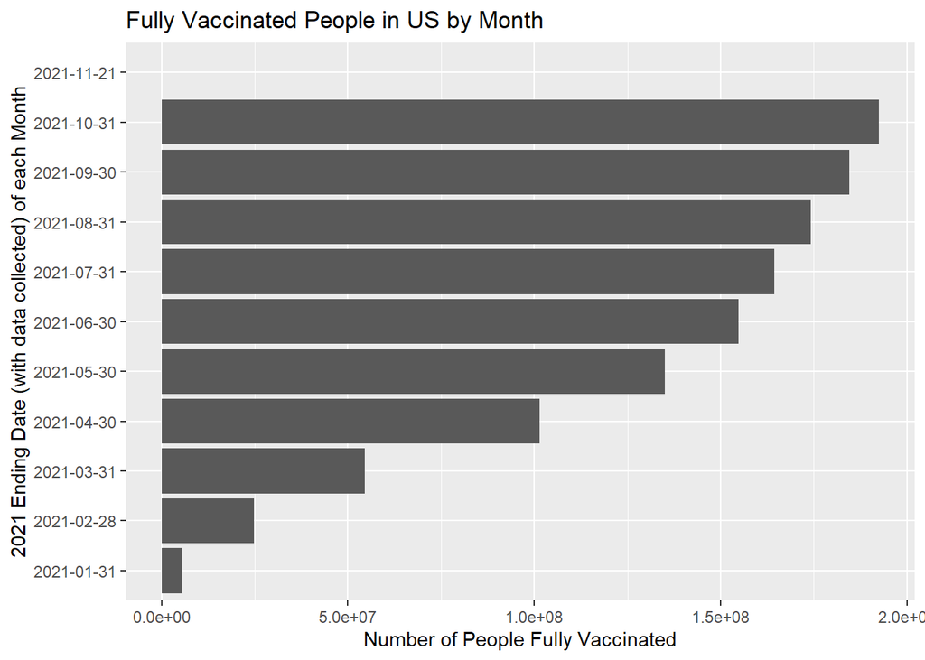

*PURPOSE:* This bar chart shows the number of fully vaccinated people by the end of each month in the US. The purpose of this chart is to visualize how many people are fully vaccinated currently and how the US as a whole has progressed by each month during the year of 2021. We excluded the 2020 data, since there was a incredibly small possibility people were fully vaccinated then since the vaccine had just been approved for usage and the two doses require a three week period.

*INSIGHTS:* We noticed how there were large leaps in fully vaccinated people from March to April to May. This may be a sign of states allowing everyone beyond the elderly and immunocompromised being eligible for vaccines. The rate of fully vaccinated people increasing seems to have slowed down despite a significant portion of the American population still not being fully vaccinated. However, this slow growth may also be a positive indicator that such a significant population is fully vaccinated that it may be enough to generate herd immunity.

## Chart 2: Scatterplot

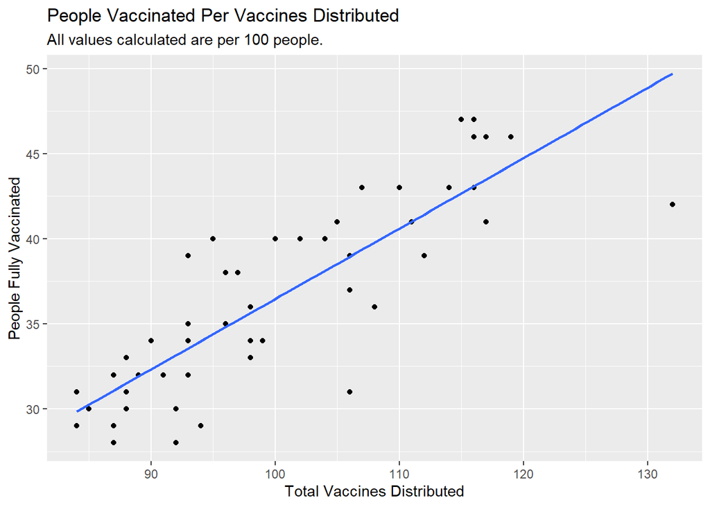

*PURPOSE:* This scatter plot compares two continuous variables: Total Vaccines Distributed per 100 People and People Fully Vaccinated per 100 People. The purpose of this plot was to see the relationship between vaccines distributed, and whether they were being used to fully vaccinate people.

*INSIGHTS:* From looking at this scatter plot, we can see that there is a strong positive correlation between the rate of people vaccinated and the rate of vaccines distributed. However, we can also see that the correlation could be much higher. On a few occasions, we see states with plenty of vaccines distributed that still have a lower vaccination rate than others with fewer vaccines distributed. This could be for two reasons that I can think of. Either the people in that state are less wanting to get vaccinated, or the state has a policy, like London does, where they prioritize first doses before scheduling people for their second. The latter reason would lower the rate of people fully vaccinated, although the vaccines are still being put to use.

## Chart 3: Map

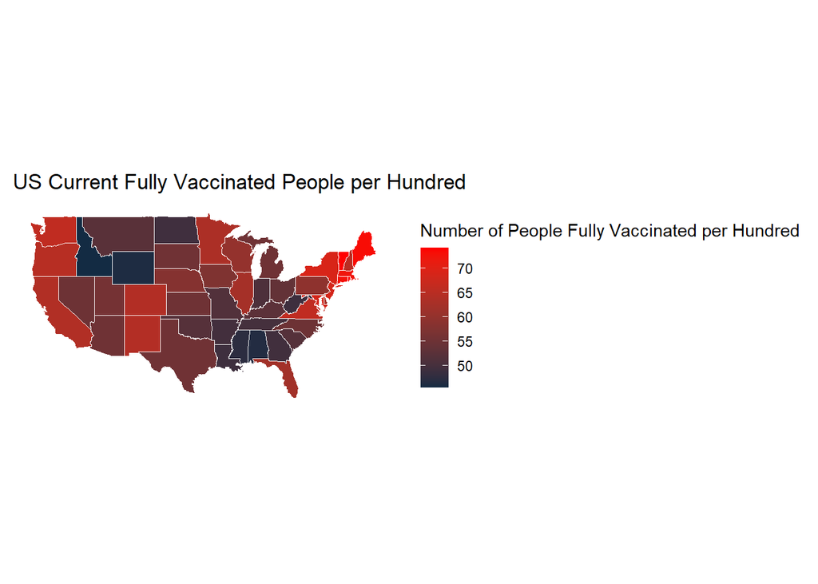

*PURPOSE:* We created a map of the proportion of people currently fully vaccinated per hundred to understand which states and regions are leading in terms of their proportion of residents fully vaccinated. The brighter the shade of red, the higher the rate is of fully vaccinated folks and is it gets darker blue, the lower the rate is.

*INSIGHTS:* As we can see, the coastal states of the West Coast and Northeastern states have higher rates of fully vaccinated people per hundred in comparison to the deep South. This could be correlated to stricter vaccination policies in the coastal states for people returning to their workplaces and schools and for visitng public establishments. If so, these higher rates are a sign that these policies are effective in incentivising vaccinations.